# GAM en series de tiempo: Prophet

Juan Manuel Barriola y Diego Kozlowski

10-11-2018

```r
library(dplyr)
library(ggplot2)
library(prophet)
library(lubridate)
```

## Exploratorias

```r
shopping <- read.csv('local-shopping_prophet.csv') %>%
  rename(.,visitantes=Total.de.Visitantes) %>%
  mutate(Dia = ymd(Dia))
glimpse(shopping)
```

```
Observations: 228
Variables: 3
$ Dia        <date> 2017-09-14, 2017-09-15, 2017-09-16, 2017-09-17, 2017-09-18, 2017-09-19, 2017-09-20, 2017-09-21, 2017-09-22, 2017-09-23, 201...
$ visitantes <int> 589, 696, 1034, 940, 540, 526, 312, 553, 639, 793, 745, 8, 333, 568, 352, 393, 497, 578, 563, 520, 413, 8, 350, 765, 1071, 5...
$ Clima      <fct> Parcialmente Nublado, Soleado, Soleado, Parcialmente Nublado, Soleado, Soleado, Soleado, Nublado, Soleado, Soleado, Parcialm...
```

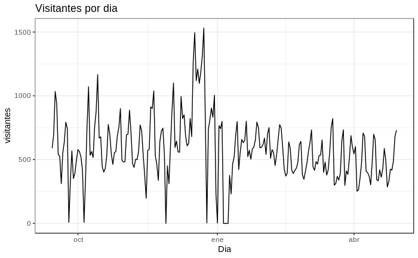

```r
ggplot(shopping, aes(Dia, visitantes)) + geom_line() + theme_bw() + labs(title='Visitantes por dia')
```

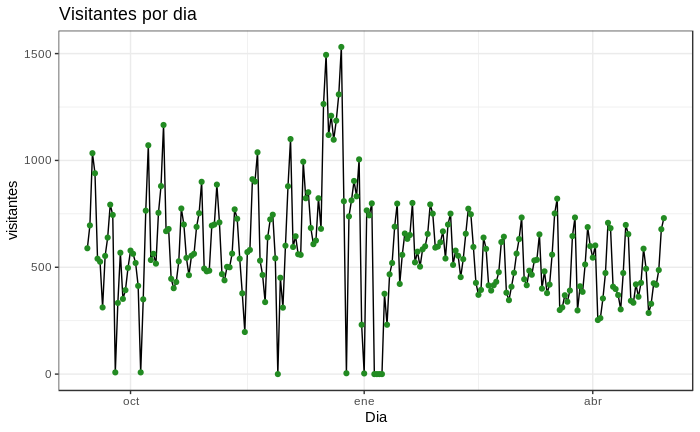

```r
 ggplot(shopping, aes(Dia, visitantes)) + geom_line() + geom_point(color='forestgreen') + theme_bw() + labs(title='Visitantes por dia')
```

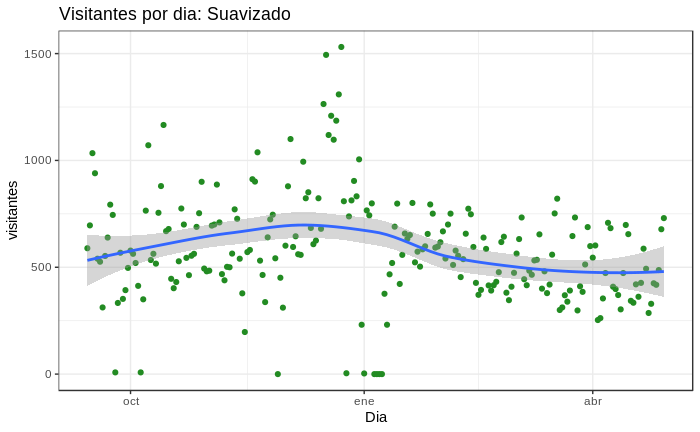

```r
ggplot(shopping, aes(Dia, visitantes)) + geom_point(color='forestgreen') + geom_smooth() + theme_bw() + labs(title='Visitantes por dia: Suavizado')
```

## Pruebas LOESS

```r
loess=stats::loess(visitantes~as.numeric(Dia), data = shopping, na.action = 'na.exclude', model = T, span=0.01)
```

[output not shown]

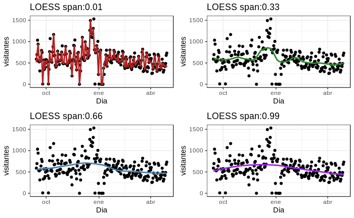

```r
shopping['loess']=predict(loess,shopping)
loess_1 = ggplot(shopping, aes(Dia,visitantes)) + geom_point() + geom_line(aes(y=loess), color='firebrick', size=1) +
  labs(title= "LOESS span:0.01") + theme_bw()
loess=stats::loess(visitantes~as.numeric(Dia), data = shopping, na.action = 'na.exclude', model = T, span=0.33)
shopping['loess']=predict(loess,shopping)
loess_2 = ggplot(shopping, aes(Dia,visitantes)) + geom_point() + geom_line(aes(y=loess), color='forestgreen', size=1) +
  labs(title= "LOESS span:0.33") + theme_bw()
loess=stats::loess(visitantes~as.numeric(Dia), data = shopping, na.action = 'na.exclude', model = T, span=0.66)
shopping['loess']=predict(loess,shopping)
loess_3 = ggplot(shopping, aes(Dia,visitantes)) + geom_point() + geom_line(aes(y=loess), color='steelblue', size=1) +
  labs(title= "LOESS span:0.66") + theme_bw()
loess=stats::loess(visitantes~as.numeric(Dia), data = shopping, na.action = 'na.exclude', model = T, span=0.99)
shopping['loess']=predict(loess,shopping)
loess_4 = ggplot(shopping, aes(Dia,visitantes)) + geom_point() + geom_line(aes(y=loess), color='purple', size=1) +
  labs(title= "LOESS span:0.99") + theme_bw()
cowplot::plot_grid(loess_1, loess_2, loess_3,loess_4)
```

## Preparacion del dataset

Prophet requiere que le pasemos el dataset con:

- **ds**: la variable temporal
- **y**: la variable a predecir

```r
# Eliminamos observaciones con menos de 250 visitantes (cuestion de negocio)
shopping[shopping['visitantes']<250,'visitantes'] = NA
# Creamos el dataset
prophet_df = shopping %>% select(Dia, visitantes) %>% rename(., ds=Dia, y=visitantes)
```

## Modelo

Hay muchos parametros para tener en cuenta. Veremos algunos:

- **df**: dataframe
- **growth**: tipo de tendencia: lineal o logistica
- **yearly.seasonality**: hay estacionalidad anual?
- **yearly.seasonality**: hay estacionalidad diaria?
- **holidays**: dataframe con fechas de vacaciones/eventos especiales

### Modelo basico

La funcion `prophet` crea el modelo, podemos pasarle o no el dataframe.

```r
# Llamamos solo al modelo
prophet_base=prophet()
# Le pasamos el dataset
prophet_base = fit.prophet(m = prophet_base, prophet_df)
```

```
Disabling yearly seasonality. Run prophet with yearly.seasonality=TRUE to override this.
Disabling daily seasonality. Run prophet with daily.seasonality=TRUE to override this.
```

```
Initial log joint probability = -4.68957
Optimization terminated normally:
  Convergence detected: absolute parameter change was below tolerance
```

Fijense que el modelo automaticamente deshabilita la estacionalidad anual y diaria.

#### Grafico del modelo

Llamando a `plot` obtenemos el valor predicho del modelo y el valor original.

Es dificil de notar pero el modelo realiza predicciones aun para los dias en los cuales no hay datos.

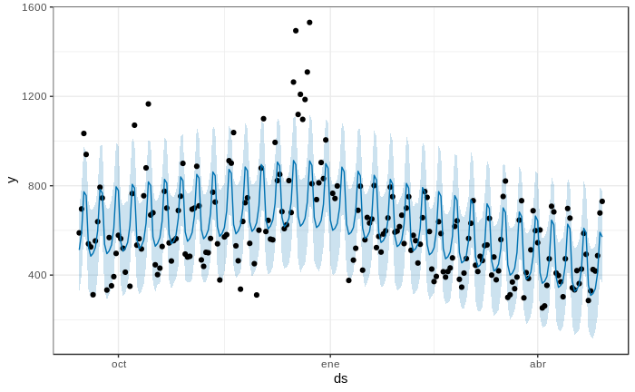

```r
plot(prophet_base,fcst=predict(prophet_base, prophet_df)) +theme_bw()
```

#### Componentes del modelo

La funcion `prophet_plot_components` nos devuelve los efectos de los componentes en nuestra variable a predecir

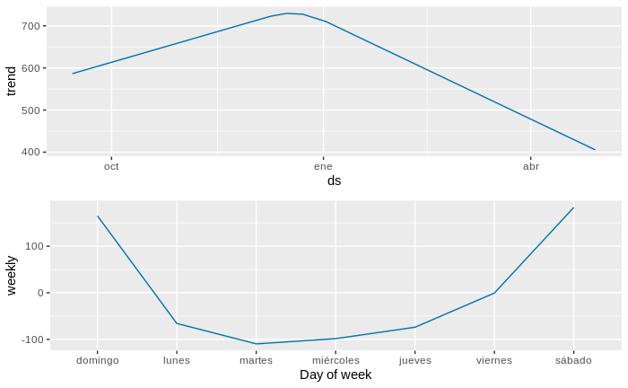

```r
prophet_plot_components(prophet_base, fcst=predict(prophet_base, prophet_df)) +theme_bw()
```

#### Diagnostico del modelo

La funcion `cross_validation` permite realizar pronosticos realizando un esquema de cross-validation temporal y, a partir de ellos, obtener ciertas metricas de performance.

- **horizon**: horizonte del pronostico
- **period**: periodo entre fechas de analisis
- **initial**: periodo inicial de entrenamiento

```r
cv_base = cross_validation(prophet_base, initial = 45, period = 7, horizon = 15, units = 'days')
```

```
Making 24 forecasts with cutoffs between 2017-11-04 and 2018-04-14
```

[output not shown]

[output cut: 17 more lines]

[output not shown]

```r
cv_base
```

| ds | y | yhat | yhat_lower | yhat_upper | cutoff |
| --- | --- | --- | --- | --- | --- |
| 2017-11-05 | 710 | 828.8292 | 646.42988 | 998.6408 | 2017-11-04 |
| 2017-11-06 | 468 | 583.6559 | 421.01372 | 761.0693 | 2017-11-04 |
| 2017-11-07 | 439 | 502.5868 | 338.89968 | 673.6105 | 2017-11-04 |
| 2017-11-08 | 502 | 490.4625 | 331.12285 | 656.6680 | 2017-11-04 |
| 2017-11-09 | 500 | 591.0459 | 419.89614 | 765.9357 | 2017-11-04 |
| 2017-11-10 | 564 | 639.5798 | 476.41024 | 812.4433 | 2017-11-04 |
| 2017-11-11 | 771 | 863.4232 | 697.87803 | 1038.1902 | 2017-11-04 |
| 2017-11-12 | 727 | 835.4909 | 655.20918 | 1011.1047 | 2017-11-04 |
| 2017-11-13 | 540 | 590.3177 | 426.96310 | 762.9520 | 2017-11-04 |
| 2017-11-14 | 378 | 509.2485 | 343.30824 | 670.3778 | 2017-11-04 |

[output cut: 328 more lines]

La funcion `performance_metrics` computa varias metricas de performance a partir de un dataframe de cross validation de prophet

```r
performance_metrics(cv_base, rolling_window = 0.5)
```

|  | horizon | mse | rmse | mae | mape | coverage |
| --- | --- | --- | --- | --- | --- | --- |
| 166 | 8 days | 44693.53 | 211.4084 | 149.1865 | 0.2336534 | 0.7751479 |
| 181 | 8 days | 44728.63 | 211.4914 | 149.3212 | 0.2337456 | 0.7751479 |
| 196 | 8 days | 44999.90 | 212.1318 | 150.2154 | 0.2354206 | 0.7751479 |
| 211 | 8 days | 44992.96 | 212.1154 | 150.1856 | 0.2356882 | 0.7751479 |
| 226 | 8 days | 44978.56 | 212.0815 | 150.0730 | 0.2355448 | 0.7751479 |
| 241 | 8 days | 44426.89 | 210.7769 | 148.3514 | 0.2340338 | 0.7810651 |
| 256 | 8 days | 44661.22 | 211.3320 | 149.5046 | 0.2354395 | 0.7810651 |
| 271 | 8 days | 42546.82 | 206.2688 | 146.5958 | 0.2339764 | 0.7869822 |
| 286 | 8 days | 41723.58 | 204.2635 | 144.6489 | 0.2317360 | 0.7928994 |
| 301 | 8 days | 41406.61 | 203.4861 | 143.6888 | 0.2306376 | 0.7988166 |

[output cut: 160 more lines]

### Modelo con estacionalidad mensual

La funcion `add_seasonality` nos permite agregar nuevas estacionalidades. Definimos:

- **m**: modelo
- **name**: nombre de la estacionalidad
- **period**: cantidad de dias del periodo
- **fourier.order**: orden de la serie de fourier para modelar la estacionalidad

```r
# Llamamos solo al modelo
prophet_mensual=prophet()
# Agregamos la estacionalidad mensual
prophet_mensual=add_seasonality(prophet_mensual, name='monthly', period=30.5, fourier.order = 4)
# Le pasamos el dataset
prophet_mensual = fit.prophet(m = prophet_mensual, prophet_df)
```

```
Disabling yearly seasonality. Run prophet with yearly.seasonality=TRUE to override this.
Disabling daily seasonality. Run prophet with daily.seasonality=TRUE to override this.
```

```
Initial log joint probability = -4.68957
Optimization terminated normally:
  Convergence detected: absolute parameter change was below tolerance
```

Fijense que el modelo automaticamente deshabilita la estacionalidad anual y diaria.

#### Grafico del modelo

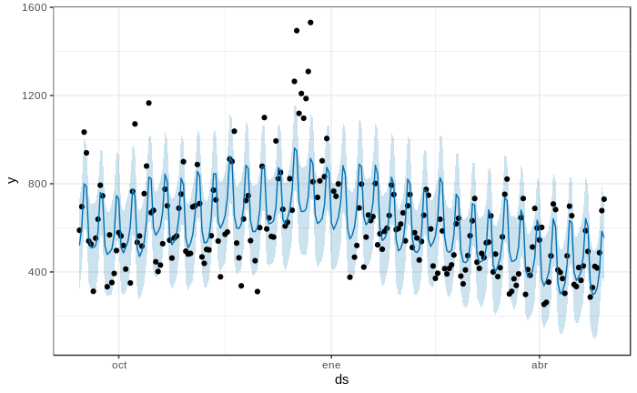

```r
plot(prophet_mensual,fcst=predict(prophet_mensual, prophet_df)) +theme_bw()
```

#### Componentes del modelo

La funcion `prophet_plot_components` nos devuelve los efectos de los componentes en nuestra variable a predecir

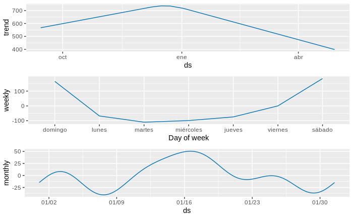

```r
prophet_plot_components(prophet_mensual, fcst=predict(prophet_mensual, prophet_df)) +theme_bw()
```

#### Diagnostico del modelo

| ds | y | yhat | yhat_lower | yhat_upper | cutoff |
| --- | --- | --- | --- | --- | --- |
| 2017-11-05 | 710 | 823.8411 | 682.27158 | 965.4136 | 2017-11-04 |
| 2017-11-06 | 468 | 547.3623 | 406.35162 | 691.3622 | 2017-11-04 |
| 2017-11-07 | 439 | 461.1264 | 314.85197 | 595.1615 | 2017-11-04 |
| 2017-11-08 | 502 | 500.4210 | 353.02001 | 637.9625 | 2017-11-04 |
| 2017-11-09 | 500 | 670.5516 | 529.73723 | 806.9035 | 2017-11-04 |
| 2017-11-10 | 564 | 816.6520 | 681.90272 | 958.5158 | 2017-11-04 |
| 2017-11-11 | 771 | 1097.4529 | 963.78758 | 1237.6006 | 2017-11-04 |
| 2017-11-12 | 727 | 1071.9741 | 937.56482 | 1200.8063 | 2017-11-04 |
| 2017-11-13 | 540 | 790.2083 | 645.81290 | 929.0097 | 2017-11-04 |
| 2017-11-14 | 378 | 650.3316 | 516.88972 | 799.4280 | 2017-11-04 |

[output cut: 328 more lines]

La funcion `performance_metrics` computa varias metricas de performance a partir de un dataframe de cross validation de prophet

```r
performance_metrics(cv_mensual, rolling_window = 0.5)
```

|  | horizon | mse | rmse | mae | mape | coverage |
| --- | --- | --- | --- | --- | --- | --- |
| 166 | 8 days | 51530.64 | 227.0036 | 162.5155 | 0.2605113 | 0.6982249 |
| 181 | 8 days | 51483.73 | 226.9003 | 162.2616 | 0.2601049 | 0.6982249 |
| 196 | 8 days | 51773.26 | 227.5374 | 162.7738 | 0.2614477 | 0.6982249 |
| 211 | 8 days | 51672.29 | 227.3154 | 162.3380 | 0.2611722 | 0.7041420 |
| 226 | 8 days | 51691.84 | 227.3584 | 162.4875 | 0.2613836 | 0.7041420 |
| 241 | 8 days | 51261.75 | 226.4106 | 161.2246 | 0.2604687 | 0.7100592 |
| 256 | 8 days | 51362.19 | 226.6323 | 161.7564 | 0.2611290 | 0.7100592 |
| 271 | 8 days | 49774.37 | 223.1017 | 159.3499 | 0.2600387 | 0.7159763 |
| 286 | 8 days | 49179.15 | 221.7637 | 157.5657 | 0.2578900 | 0.7218935 |
| 301 | 8 days | 48807.12 | 220.9233 | 156.6219 | 0.2568537 | 0.7278107 |

[output cut: 160 more lines]

### Modelo completo

Como ultimo paso vamos a agregar las ventas de navidad y ciertos dias de promociones como eventos especiales

#### Dataframe de eventos

Creamos el dataframe de eventos con: nombre del evento, fechas y una “ventana” para definir si el evento se estira a ciertos dias.

```r
christmas = data.frame(holiday= 'christmas',
  ds=ymd(c('2017-12-16','2017-12-17','2017-12-18',
                        '2017-12-19','2017-12-20','2017-12-21',
                        '2017-12-22','2017-12-23')),
  lower_window= 0,
  upper_window= 0)
big_sales = data.frame(
  holiday= 'big_sales',
  ds= ymd(c('2017-09-16','2017-10-08','2017-10-14',
                        '2017-11-20','2017-12-03','2017-12-30')),
  lower_window= 0,
  upper_window= 0)
holidays= bind_rows(christmas, big_sales)
```

```
Unequal factor levels: coercing to characterbinding character and factor vector, coercing into character vectorbinding character and factor vector, coercing into character vector
```

```r
glimpse(holidays)
```

```
Observations: 14
Variables: 4
$ holiday      <chr> "christmas", "christmas", "christmas", "christmas", "christmas", "christmas", "christmas", "christmas", "big_sales", "big_...
$ ds           <date> 2017-12-16, 2017-12-17, 2017-12-18, 2017-12-19, 2017-12-20, 2017-12-21, 2017-12-22, 2017-12-23, 2017-09-16, 2017-10-08, 2...
$ lower_window <dbl> 0, 0, 0, 0, 0, 0, 0, 0, 0, 0, 0, 0, 0, 0
$ upper_window <dbl> 0, 0, 0, 0, 0, 0, 0, 0, 0, 0, 0, 0, 0, 0
```

```r
# Llamamos al modelo con el dataset de eventos
prophet_full=prophet(holidays = holidays)
# Agregamos la estacionalidad mensual
prophet_full=add_seasonality(prophet_full, name='monthly', period=30.5, fourier.order = 4)
# Le pasamos el dataset
prophet_full = fit.prophet(m = prophet_full, prophet_df)
```

```
Disabling yearly seasonality. Run prophet with yearly.seasonality=TRUE to override this.
Disabling daily seasonality. Run prophet with daily.seasonality=TRUE to override this.
```

```
Initial log joint probability = -4.68957
Optimization terminated normally:
  Convergence detected: absolute parameter change was below tolerance
```

Fijense que el modelo automaticamente deshabilita la estacionalidad anual y diaria.

#### Grafico del modelo

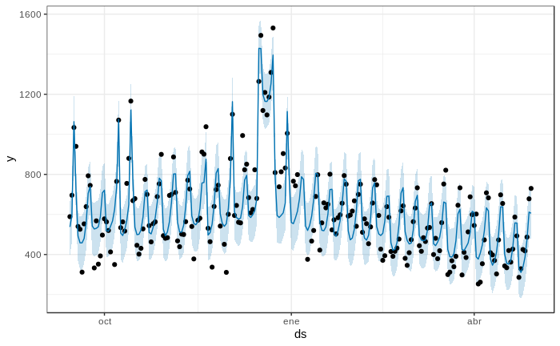

```r
plot(prophet_full,fcst=predict(prophet_full, prophet_df)) +theme_bw()
```

#### Componentes del modelo

La funcion `prophet_plot_components` nos devuelve los efectos de los componentes en nuestra variable a predecir

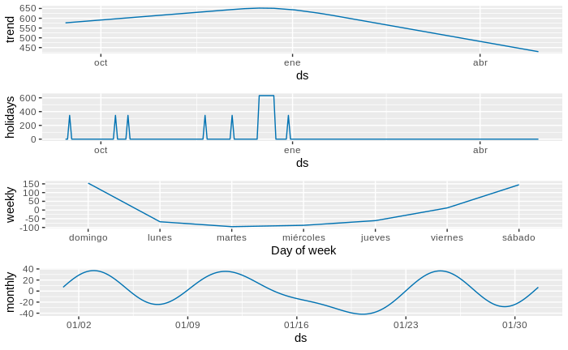

```r
prophet_plot_components(prophet_full, fcst=predict(prophet_full, prophet_df)) +theme_bw()
```

#### Diagnostico del modelo

| ds | y | yhat | yhat_lower | yhat_upper | cutoff |
| --- | --- | --- | --- | --- | --- |
| 2017-11-05 | 710 | 783.1627 | 678.1194 | 893.2234 | 2017-11-04 |
| 2017-11-06 | 468 | 521.4809 | 415.3077 | 627.7627 | 2017-11-04 |
| 2017-11-07 | 439 | 402.6993 | 285.3635 | 513.1593 | 2017-11-04 |
| 2017-11-08 | 502 | 430.6764 | 318.2551 | 545.7531 | 2017-11-04 |
| 2017-11-09 | 500 | 619.2535 | 510.6371 | 736.6238 | 2017-11-04 |
| 2017-11-10 | 564 | 792.2517 | 679.6447 | 903.7536 | 2017-11-04 |
| 2017-11-11 | 771 | 1018.5607 | 904.9112 | 1129.2027 | 2017-11-04 |
| 2017-11-12 | 727 | 1030.4046 | 923.2422 | 1142.7688 | 2017-11-04 |
| 2017-11-13 | 540 | 777.6664 | 678.0312 | 891.3474 | 2017-11-04 |
| 2017-11-14 | 378 | 606.8106 | 489.5761 | 722.7189 | 2017-11-04 |

[output cut: 328 more lines]

```r
performance_metrics(cv_full, rolling_window = 0.5)
```

|  | horizon | mse | rmse | mae | mape | coverage |
| --- | --- | --- | --- | --- | --- | --- |
| 166 | 8 days | 22962.02 | 151.5322 | 113.6740 | 0.1935432 | 0.6804734 |
| 181 | 8 days | 22948.59 | 151.4879 | 113.5696 | 0.1933579 | 0.6804734 |
| 196 | 8 days | 22896.71 | 151.3166 | 113.4371 | 0.1935369 | 0.6804734 |
| 211 | 8 days | 22897.76 | 151.3201 | 113.4409 | 0.1939022 | 0.6804734 |
| 226 | 8 days | 22878.26 | 151.2556 | 113.2004 | 0.1935826 | 0.6804734 |
| 241 | 8 days | 22798.06 | 150.9903 | 112.5861 | 0.1930732 | 0.6804734 |
| 256 | 8 days | 23041.29 | 151.7936 | 113.7577 | 0.1945015 | 0.6745562 |
| 271 | 8 days | 22888.22 | 151.2885 | 113.3264 | 0.1947925 | 0.6745562 |
| 286 | 8 days | 22888.03 | 151.2879 | 113.3228 | 0.1948820 | 0.6745562 |
| 301 | 8 days | 22903.57 | 151.3393 | 113.4189 | 0.1951136 | 0.6745562 |

[output cut: 160 more lines]

## Graficos interactivos

```r
dyplot.prophet(prophet_full, fcst=predict(prophet_full, prophet_df))
```

[interactive chart not shown]